# Homework 4

Jules Pellin

2026-05-11

## Question 1: What is Tidy Data?

Hadley Wickham’s paper defines tidy data as a standard way of organizing datasets to make analysis easier. In other words, a dataset is tidy when it follows three rules: 1) every variable forms a column; 2) every observation forms a row; 3) and every type of observational unit forms its own table. This structure makes it straightforward to filter, transform, aggregate, and visualize data because each variable is always in a consistent, predictable location.

Wickham points out that most real-world datasets are messy, and identifies five common problems: 1) column headers that are values instead of variable names; 2) multiple variables stored in one column; 3)variables stored in both rows and columns, 4) multiple types of observations in one table, 5) and one type of observation spread across multiple tables. Each of these problems requires a different tidying technique, such as melting (stacking columns into rows) or casting (rotating rows back into columns).

The practical importance of tidy data is that it works seamlessly with tidy tools functions that take tidy input and return tidy output. So, for example, in R, packages like ggplot2 and dplyr are designed around tidy data, meaning that once your data is tidy, analysis and visualization become much simpler and faster.

## Question 2

For Question 2, I loaded the COVID-19 dataset directly from GitHub and filtered it to European countries with a population over 1 million. I then aggregated new cases per million by month and country, identified the six countries with the highest case rates in April, and produced a log2 line chart highlighting those six countries. I repeated the same process for October.

```r
# Load required packages
library(tidyverse)
library(lubridate)
library(gghighlight)
```

```r
# Load COVID-19 data from GitHub URL
covid_df <- read.csv(
  "https://raw.githubusercontent.com/owid/covid-19-data/master/public/data/owid-covid-data.csv",
  header = TRUE
)

# Convert date column to Date type
covid_df$date <- as.Date(covid_df$date)

# Filter to Europe + population > 1 million
europe_df <- covid_df %>%
  filter(continent == "Europe") %>%
  filter(population > 1000000)

# Create month column
europe_df <- europe_df %>%
  mutate(month = floor_date(date, "month"))

# Summarise cases per month per country
plot_data <- europe_df %>%
  group_by(location, month) %>%
  summarise(cases_per_month = sum(new_cases_per_million, na.rm = TRUE)) %>%
  ungroup()
```

```
## `summarise()` has regrouped the output.
## ℹ Summaries were computed grouped by location and month.
## ℹ Output is grouped by location.
## ℹ Use `summarise(.groups = "drop_last")` to silence this message.
## ℹ Use `summarise(.by = c(location, month))` for per-operation grouping
##   (`?dplyr::dplyr_by`) instead.
```

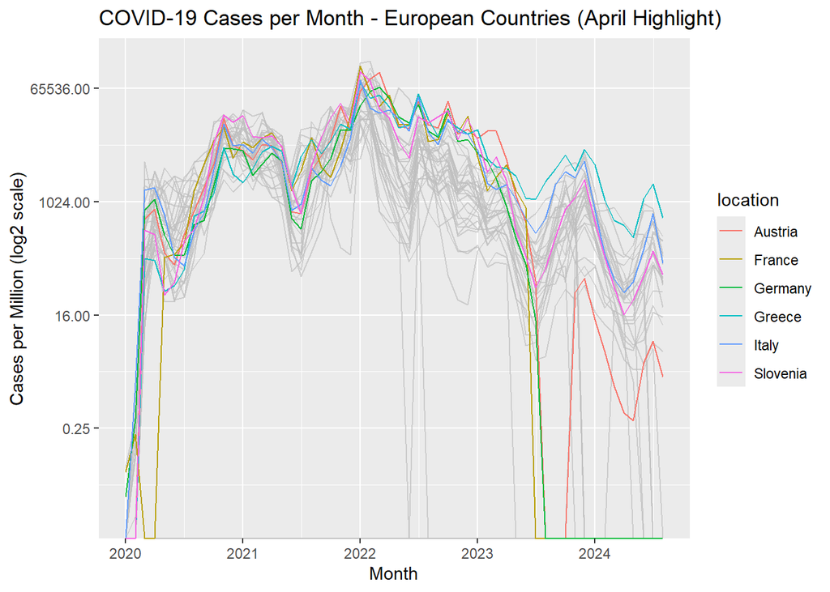

```r
# Find top 6 countries by April cases
top6_april <- plot_data %>%
  filter(format(month, "%m") == "04") %>%
  group_by(location) %>%
  summarise(april_total = sum(cases_per_month, na.rm = TRUE)) %>%
  arrange(desc(april_total)) %>%
  slice_head(n = 6)

# Add flag column for April top 6
plot_data <- plot_data %>%
  mutate(april_high = ifelse(location %in% top6_april$location, 1, 0))

# Plot: April highlight
ggplot(plot_data,
       aes(x = month, y = cases_per_month,
           group = location, color = location)) +
  geom_line() +
  gghighlight(april_high == 1, use_direct_label = FALSE) +
  scale_y_continuous(trans = "log2") +
  labs(title = "COVID-19 Cases per Month - European Countries (April Highlight)",
       x = "Month", y = "Cases per Million (log2 scale)")
```

### Q2b - October

The following plot repeats the same analysis but highlights the six countries with the highest COVID-19 case rates in October instead of April.

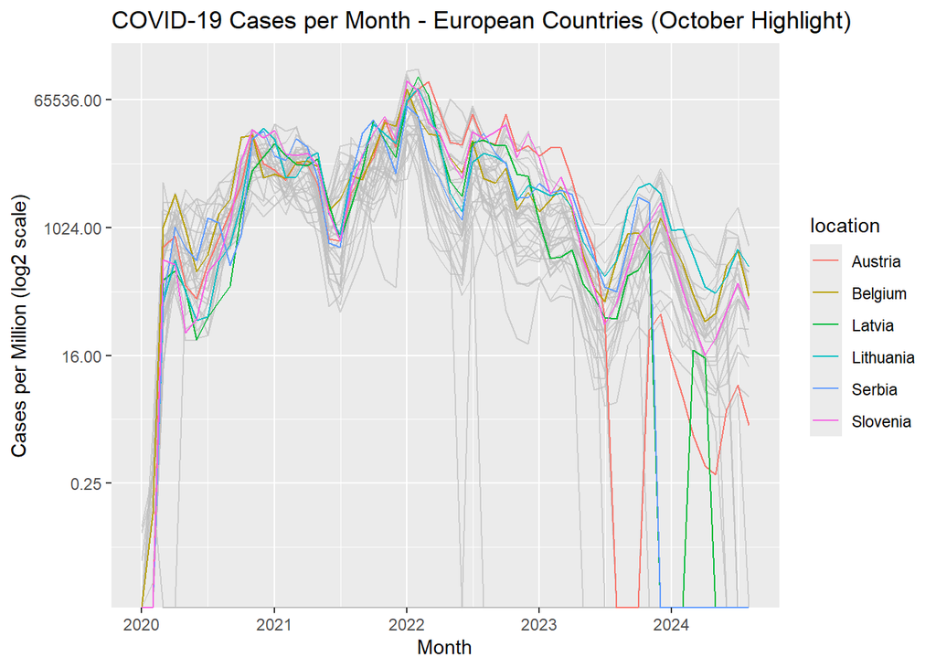

```r
# Find top 6 countries by October cases
top6_oct <- plot_data %>%
  filter(format(month, "%m") == "10") %>%
  group_by(location) %>%
  summarise(oct_total = sum(cases_per_month, na.rm = TRUE)) %>%
  arrange(desc(oct_total)) %>%
  slice_head(n = 6)

# Add flag column for October top 6
plot_data <- plot_data %>%
  mutate(oct_high = ifelse(location %in% top6_oct$location, 1, 0))

# Plot: October highlight
ggplot(plot_data,
       aes(x = month, y = cases_per_month,
           group = location, color = location)) +
  geom_line() +
  gghighlight(oct_high == 1, use_direct_label = FALSE) +
  scale_y_continuous(trans = "log2") +
  labs(title = "COVID-19 Cases per Month - European Countries (October Highlight)",
       x = "Month", y = "Cases per Million (log2 scale)")
```

## Question 3

For Question 3, I repeated the same pipeline but used new_deaths_per_million instead of new_cases_per_million to show monthly death rates. I highlighted the six countries with the highest death rates for April and then October.

```r
# Summarise DEATHS per month per country
death_data <- europe_df %>%
  group_by(location, month) %>%
  summarise(deaths_per_month = sum(new_deaths_per_million, na.rm = TRUE)) %>%
  ungroup()
```

```
## `summarise()` has regrouped the output.
## ℹ Summaries were computed grouped by location and month.
## ℹ Output is grouped by location.
## ℹ Use `summarise(.groups = "drop_last")` to silence this message.
## ℹ Use `summarise(.by = c(location, month))` for per-operation grouping
##   (`?dplyr::dplyr_by`) instead.
```

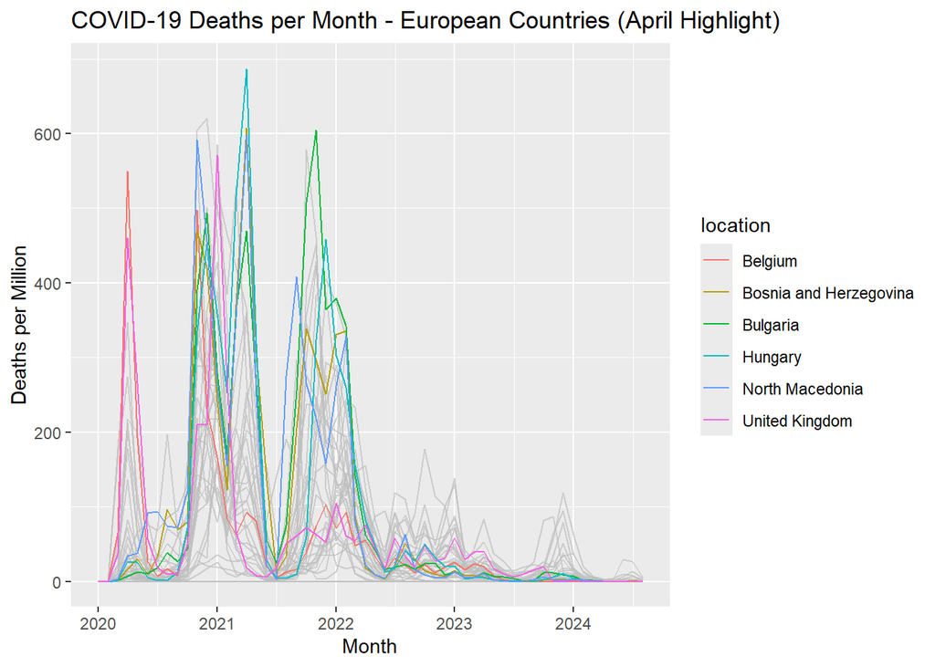

```r
# Find top 6 countries by April deaths
top6_april_d <- death_data %>%
  filter(format(month, "%m") == "04") %>%
  group_by(location) %>%
  summarise(april_total = sum(deaths_per_month, na.rm = TRUE)) %>%
  arrange(desc(april_total)) %>%
  slice_head(n = 6)

# Add flag column
death_data <- death_data %>%
  mutate(april_high = ifelse(location %in% top6_april_d$location, 1, 0))

# Plot: April deaths
ggplot(death_data,
       aes(x = month, y = deaths_per_month,
           group = location, color = location)) +
  geom_line() +
  gghighlight(april_high == 1, use_direct_label = FALSE) +
  labs(title = "COVID-19 Deaths per Month - European Countries (April Highlight)",
       x = "Month", y = "Deaths per Million")
```

### Q3b - October

The following plot repeats the same analysis but highlights the six countries with the highest COVID-19 death rates in October instead of April.

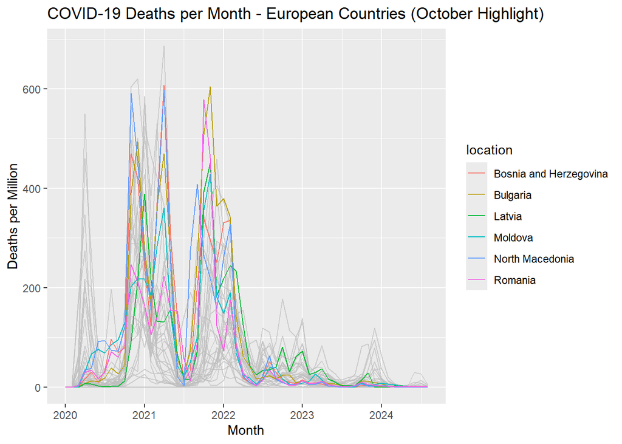

```r
# Find top 6 countries by October deaths
top6_oct_d <- death_data %>%
  filter(format(month, "%m") == "10") %>%
  group_by(location) %>%
  summarise(oct_total = sum(deaths_per_month, na.rm = TRUE)) %>%
  arrange(desc(oct_total)) %>%
  slice_head(n = 6)

# Add flag column for October
death_data <- death_data %>%
  mutate(oct_high = ifelse(location %in% top6_oct_d$location, 1, 0))

# Plot: October deaths
ggplot(death_data,
       aes(x = month, y = deaths_per_month,
           group = location, color = location)) +
  geom_line() +
  gghighlight(oct_high == 1, use_direct_label = FALSE) +
  labs(title = "COVID-19 Deaths per Month - European Countries (October Highlight)",
       x = "Month", y = "Deaths per Million")
```